***DISCLAIMER: some prerequisite cells that are not helful for the visualization have been removed, more information can be found in the full notebook on github: https://github.com/mkowa2/Data_Bandits_CS418***

# Introduction

Our project's goal is that of investigating a possible correlation between metheorological conditions and corn prices in the U.S.A.. In order to do that we will gather data pertaining both weather and corn and we will try to extract some knowledge from it.

# Data cleaning and wrangling

### Weather data

The weather dataset consists of data collected from various sensors across the U.S. on different days. It includes measurements of maximum temperature, minimum temperature, and precipitation amounts.

We performed data cleaning by:

- Removing NaN values.
- Converting temperatures to degrees Celsius.
- Removing corrupted values.
- Selecting only data within the Corn Belt region, defined by latitude (36.5°–45°) and longitude (-97°–-84°).

The cleaned data has been saved to the cleaned_weather.csv file and imported into this document.

For the EDA:

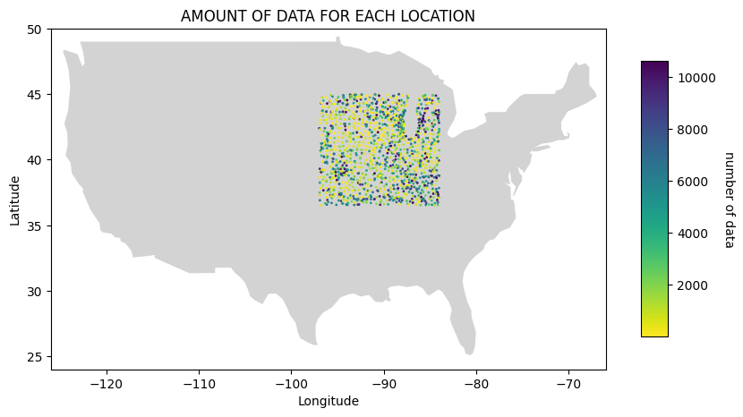

```python
# compute the amount of collected weather data for each location
w_by_coordinates = weather_data.groupby(['Longitude','Latitude']).size().reset_index(name="count")
min = w_by_coordinates['count'].min()
max = w_by_coordinates['count'].max()
norm = plt.Normalize(vmin=min, vmax=max)
# visualize on the map
colors = plt.cm.viridis(norm(w_by_coordinates['count']))
url = 'https://raw.githubusercontent.com/datasets/geo-boundaries-world-110m/master/countries.geojson'
world = gpd.read_file(url)
usa = world[(world['admin'] == 'United States of America')]
fig, ax = plt.subplots(figsize=(10, 8))
usa.plot(ax=ax, color='lightgrey')
plt.scatter(w_by_coordinates['Longitude'], w_by_coordinates['Latitude'], color=colors, marker='o', s=1)
cbar = plt.colorbar(mappable=plt.cm.ScalarMappable(norm=norm, cmap='viridis_r'), ax=ax, shrink=0.5, aspect=10)
cbar.set_label("number of data", rotation=270, labelpad=15)
ax.set_xlim([-126, -66])
ax.set_ylim([24, 50])
plt.xlabel("Longitude")
plt.ylabel("Latitude")
ax.set_title("AMOUNT OF DATA FOR EACH LOCATION");
```

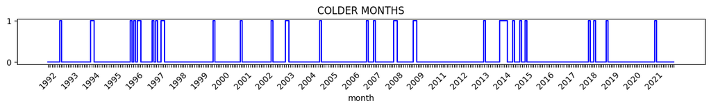

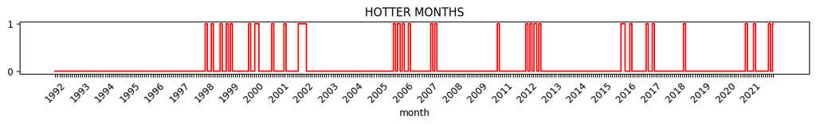

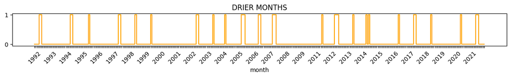

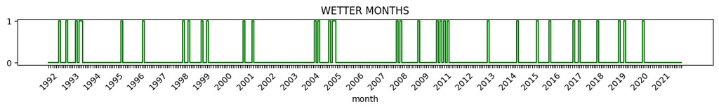

```python
# plot exceptional month for COLD, HOT, DRY and WET
plt.figure(figsize=(15, 1))
plt.step(d_exceptional_grouped["DATE"], d_exceptional_grouped["colder"], where='mid', color='blue')
plt.xlabel("month")
plt.title("COLDER MONTHS")
plt.xticks(ticks=range(len(d_exceptional_grouped['DATE'])), labels=d_exceptional_grouped['LABEL'], rotation=45)
plt.figure(figsize=(15, 1))
plt.step(d_exceptional_grouped["DATE"], d_exceptional_grouped["hotter"], where='mid', color='red')
plt.xlabel("month")
plt.title("HOTTER MONTHS")
plt.xticks(ticks=range(len(d_exceptional_grouped['DATE'])), labels=d_exceptional_grouped['LABEL'], rotation=45)
plt.figure(figsize=(15, 1))
plt.step(d_exceptional_grouped["DATE"], d_exceptional_grouped["drier"], where='mid', color='orange')
plt.xlabel("month")
plt.title("DRIER MONTHS")
plt.xticks(ticks=range(len(d_exceptional_grouped['DATE'])), labels=d_exceptional_grouped['LABEL'], rotation=45)
plt.figure(figsize=(15, 1))
plt.step(d_exceptional_grouped["DATE"], d_exceptional_grouped["wetter"], where='mid', color='green')
plt.xlabel("month")
plt.title("WETTER MONTHS")
plt.xticks(ticks=range(len(d_exceptional_grouped['DATE'])), labels=d_exceptional_grouped['LABEL'], rotation=45);
```

### Corn data

We present the already cleaned major producers, more info in the full notebook

```python
# Create a map centered in the US
m = folium.Map(location=[39.8283, -98.5795], zoom_start=4, tiles="cartodb positron")
scaling_factor = 60000000

# Color scale used to show the production of corn
max_production = merged_data['PRODUCTION in BU'].astype(float).max()
colormap = LinearColormap(colors=['lightyellow', 'orange', 'darkorange', 'brown'],
                          vmin=0, vmax=max_production, caption="Corn Production in Bushels")

# Title to add to the map
title_html = '''
    <h3 align="center" style="font-size:16px"><b>Corn Production Visualization by State</b></h3>
'''
m.get_root().html.add_child(folium.Element(title_html))

# Legend of the map
legend_html = '''
     <div style="position: fixed;
                 bottom: 50px; left: 50px; width: 200px; height: 100px;
                 background-color: white; border:2px solid grey; z-index:9999; font-size:14px;
                 padding: 10px;">
     <b>Legend</b><br>
     <i style="background:brown; width:10px; height:10px; float:left; margin-right:5px; opacity:0.7;"></i> High Production<br>
     <i style="background:lightyellow; width:10px; height:10px; float:left; margin-right:5px; opacity:0.7;"></i> Low Production<br>
     <i style="background:white; width:10px; height:10px; float:left; margin-right:5px; border:1px solid black;"></i> No Data
     </div>
'''
m.get_root().html.add_child(folium.Element(legend_html))

# Add circle markers for each state
for _, row in merged_data.iterrows():
    if pd.notnull(row['latitude']) and pd.notnull(row['longitude']):
        radius = float(row['PRODUCTION in BU']) / scaling_factor
        color = colormap(float(row['PRODUCTION in BU']))  # Get color from colormap based on production

        folium.CircleMarker(
            location=(row['latitude'], row['longitude']),
            radius=radius,
            color="black",
            fill=True,
            fill_color=color,  # Fill with gradient color based on production
            fill_opacity=0.6,
            tooltip=f"{row['Name']} - Production: {row['PRODUCTION in BU']} BU"  # Tooltip for hover
        ).add_to(m)


colormap.add_to(m)
m
```

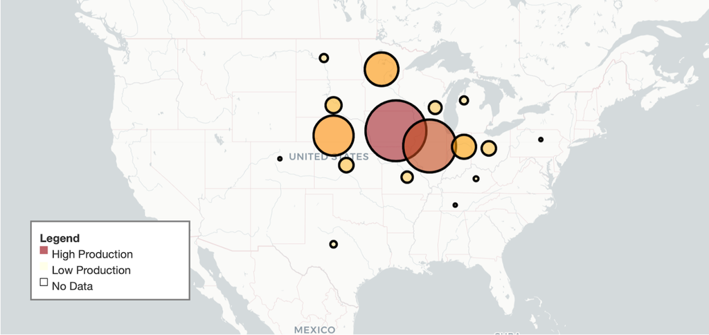

From this, through code we do not report for the sake of space, we conclude that the dataset already contains dfata from major producers except for Texas, which we choose to ignore.

Commodity Dataset Analysis

The commodity dataset consists of data collected on various agricultural commodities, including measurements of daily price ranges for Corn Futures contracts (Range_C_F1 and Range_C_F2).

Data Cleaning:

- Parsing the 'Date' column to a proper datetime format.
- Filtering data to include only records after January 1, 1992.
- Calculating the volatility difference as the difference between Range_C_F1 and Range_C_F2.

Exploratory Data Analysis (EDA):

1. Monthly Averages:
   - Computed the monthly averages of Range_C_F1, Range_C_F2, and Volatility Difference by grouping the data by year and month.
   - Visualized results to observe trends in commodity price behavior over time.
2. Outlier Analysis:
   - Identified outlier days using the Interquartile Range (IQR) method for Volatility Difference:
     - Positive Outliers: Days where Volatility Difference exceeds the upper threshold (4th quartile).
     - Negative Outliers: Days where Volatility Difference falls below the lower threshold (1st quartile).
   - Computed and visualized monthly indicators to identify months with a high count of outliers:
     - A month is marked as an outlier if its count of outliers exceeds the 0.75 quantile of monthly outlier counts.
3. Rolling Averages:
   - Calculated 30-day rolling averages for Range_C_F1, Range_C_F2, and Volatility Difference to smooth daily fluctuations and identify longer-term trends.

Visualizations:

- Compared the monthly averages of Range_C_F1, Range_C_F2, and Volatility Difference.
- Highlighted months with unusually high or low volatility differences through outlier indicators.
- Analyzed trends in the 30-day rolling averages of commodity prices and volatility differences.

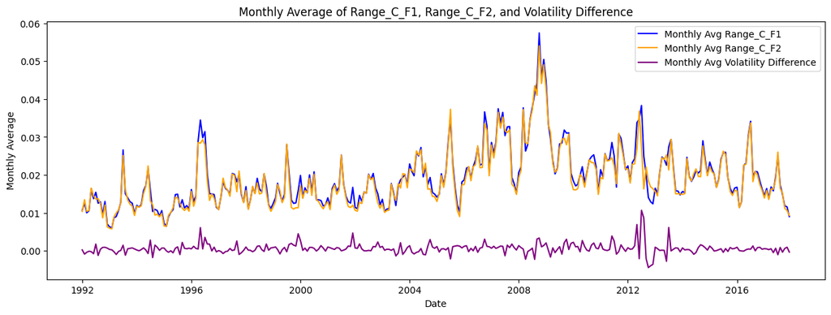

```python
plt.figure(figsize=(15, 5))
plt.plot(monthly_avg.index, monthly_avg['Range_C_F1'], label='Monthly Avg Range_C_F1', color='blue')
plt.plot(monthly_avg.index, monthly_avg['Range_C_F2'], label='Monthly Avg Range_C_F2', color='orange')
plt.plot(monthly_avg.index, monthly_avg['Volatility_Difference'], label='Monthly Avg Volatility Difference', color='purple')
plt.xlabel('Date')
plt.ylabel('Monthly Average')
plt.title('Monthly Average of Range_C_F1, Range_C_F2, and Volatility Difference')
plt.legend()
plt.show()
```

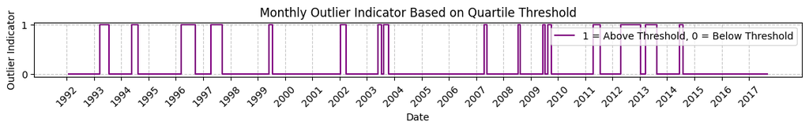

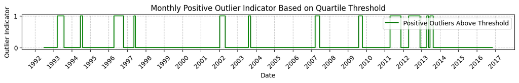

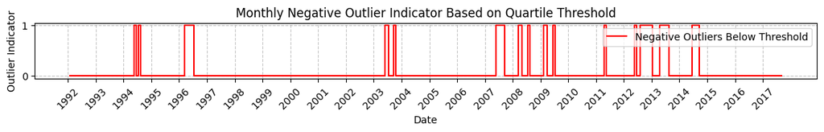

```python
plt.figure(figsize=(14, 1))
plt.step(monthly_outlier_indicator.index, monthly_outlier_indicator, where='mid', color='purple', label='1 = Above Threshold, 0 = Below Threshold')
plt.xlabel('Date')
plt.ylabel('Outlier Indicator')
plt.title('Monthly Outlier Indicator Based on Quartile Threshold')
plt.legend()
years = pd.date_range(start="1992-01-01", end=monthly_outlier_indicator.index.max(), freq='YS')
plt.xticks(years, [year.year for year in years], rotation=45)
plt.grid(True, linestyle='--', alpha=0.7)
plt.show()
plt.figure(figsize=(14, 1))
plt.step(monthly_positive_outlier_indicator.index, monthly_positive_outlier_indicator, where='mid', color='green', label='Positive Outliers Above Threshold')
plt.xlabel('Date')
plt.ylabel('Outlier Indicator')
plt.title('Monthly Positive Outlier Indicator Based on Quartile Threshold')
plt.legend()
plt.xticks(years, [year.year for year in years], rotation=45)
plt.grid(True, linestyle='--', alpha=0.7)
plt.show()
plt.figure(figsize=(14, 1))
plt.step(monthly_negative_outlier_indicator.index, monthly_negative_outlier_indicator, where='mid', color='red', label='Negative Outliers Below Threshold')
plt.xlabel('Date')
plt.ylabel('Outlier Indicator')
plt.title('Monthly Negative Outlier Indicator Based on Quartile Threshold')
plt.legend()
plt.xticks(years, [year.year for year in years], rotation=45)
plt.grid(True, linestyle='--', alpha=0.7)
plt.show()
```

## Average price of grain per bushel per state

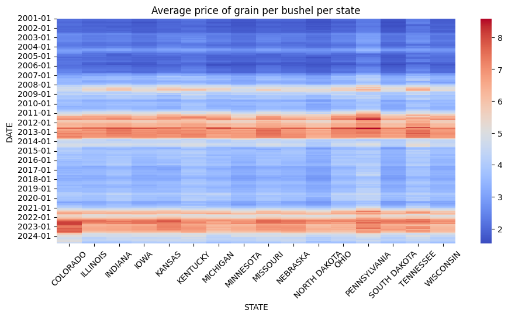

```python
plt.figure(figsize=(11, 5))
sns.heatmap(pivot_1, cmap='coolwarm')
plt.xticks(rotation=45)
year_start_months = pivot_1.index[pivot_1.index.month == 1]
y_ticks = np.arange(0, len(pivot_1.index), 12)  # assuming monthly data, every 12th row
plt.yticks(y_ticks, labels=year_start_months.strftime('%Y-%m'))
plt.title('Average price of grain per bushel per state')
plt.show()
```

## Hypothesis Testing

Let's now define a function to compute correlations for every desired time delay

### HT-1: Average correlation between weather outliers and price outliers is larger within the same month than with 1 month delay

We aim at testing whether or not the particular weather confitions affect price non-standard variations more in the same month rather with a delayed effect.

```python
t_stat, p_value = ttest_ind(correlations_0_df['Correlation'], correlations_1_df['Correlation'], alternative='greater')
alpha = 0.05
if p_value < alpha:
    print(f"Reject the null hypothesis with confidence alpha={alpha} "+\
          "with a p-value of", p_value)
else:
    print("Fail to reject the null hypothesis")
print("Null hypothesis: the average correlation between weather and price outliers within the same month is less or equal to the average correlation between weather and price outliers with a time delay of 1 month")
print("Alternative hypothesis: the average correlation between weather and price outliers within the same month is greater than the average correlation between weather and price outliers with a time delay of 1 month")
print("t-statistic: ", t_stat)
print("p-value: ", p_value)
```

```
Fail to reject the null hypothesis
Null hypothesis: the average correlation between weather and price outliers within the same month is less or equal to the average correlation between weather and price outliers with a time delay of 1 month
Alternative hypothesis: the average correlation between weather and price outliers within the same month is greater than the average correlation between weather and price outliers with a time delay of 1 month
t-statistic:  -0.13497389734521964
p-value:  0.5530700964316417
```

Hypothesis Testing on Outliers

We analyze the difference between the number of positive and negative outliers identified monthly in the dataset.

Data Preparation:

- We calculate the monthly count of positive outliers (Volatility_Difference > Q3 + 1.5 * IQR).
- We calculate the monthly count of negative outliers (Volatility_Difference < Q1 - 1.5 * IQR).
- A DataFrame `prices_t` is created, containing the monthly counts of positive and negative outliers.
- We compute the absolute difference (`DIFF`) between positive and negative outliers for each month.

Hypothesis Testing:

- Null Hypothesis (H0): The average difference between positive and negative outliers is equal to 0.
- Alternative Hypothesis (H1): The average difference between positive and negative outliers is different from 0.

Statistical Analysis:

Results:

Outputs:

- T-statistic: The computed t-statistic for the test.
- p-value: The probability of observing the data under the null hypothesis.
- Mean difference: The average of the absolute differences between positive and negative outliers.

```python
monthly_positive_outlier_count = outliers[outliers['Volatility_Difference'] > q3 + 1.5 * iqr].groupby(['Year', 'Month']).size()
monthly_negative_outlier_count = outliers[outliers['Volatility_Difference'] < q1 - 1.5 * iqr].groupby(['Year', 'Month']).size()
prices_t = pd.DataFrame({
    'Positive_Outliers': monthly_positive_outlier_count,
    'Negative_Outliers': monthly_negative_outlier_count
}).fillna(0)
prices_t['DIFF'] = abs(prices_t['Positive_Outliers'] - prices_t['Negative_Outliers'])
'''
H0: The average difference between positive and negative outliers is equal to 0
H1: The average difference between positive and negative outliers is different from 0
'''
t_stat, p_value = ttest_1samp(prices_t['DIFF'], 0, alternative='two-sided')
alpha = 0.05
if p_value < alpha:
    print(f"Reject the null hypothesis with confidence alpha={alpha} " +
          f"with a p-value of {p_value:.4f}")
else:
    print(f"Fail to reject the null hypothesis with confidence alpha={alpha}")
print(f"T-statistic: {t_stat:.4f}")
print(f"Mean difference: {prices_t['DIFF'].mean():.4f}")
```

```
Reject the null hypothesis with confidence alpha=0.05 with a p-value of 0.0000
T-statistic: 11.5855
Mean difference: 1.8601
```

## RANDOM TREES ON WEATHER PREDICT PRICE

- Model: Random forest
- Output: Corn price for each month
- Features: Minimum temperature, maximum temperature and precipitation average in the corn belt for the previous 12 months + current month number.

IDEA: We try to predict corn prices using the weather data from the past twelve months. A simple linear correlation is not enough because the position of the most important months within the feature (like the pollination month) changes depending on the month we are considering for price prediction.

RESULT: There is some correlation in the position of peaks between the real and predicted data. However, while the model performs well on the training data, it does not perform well on the test data. This may be due to the variable trends in the market, which can be influenced by several factors. For example, during an economic crisis, even if the weather is good and production increases, prices can still be high.

```python
# for each month, collect the weather data of past 12 months
def getLastYear(year, month):
    ret = []
    j = 0
    for m in range(month):
        ret.append([j,month-m,year])
        j += 1
    for m in range(12-j):
        ret.append([j,12-m,year-1])
        j += 1
    return ret
y = price_avg[(price_avg["YEAR"]>=2002) & (price_avg["YEAR"]<=2021) & (price_avg["YEAR"]!=2011) & (price_avg["YEAR"]!=2010)]
columns = []
columns.append("MONTH")
for i in range(12):
    columns.append(f"TMIN-{i}")
    columns.append(f"TMAX-{i}")
    columns.append(f"PRCP-{i}")
table = []
for _, row in y.iterrows():
    new_row = {}
    M = int(row['MONTH'])
    Y = int(row['YEAR'])
    new_row["MONTH"]=M
    new_row["YEAR"]=Y
    for i, month, year in getLastYear(Y,M):
        focus = weather_avg[(weather_avg["MONTH"]==month) & (weather_avg["YEAR"]==year)]
        new_row[f"TMIN-{i}"] = focus['TMIN'].values[0]
        new_row[f"TMAX-{i}"] = focus['TMAX'].values[0]
        new_row[f"PRCP-{i}"] = focus['PRCP'].values[0]
    table.append(new_row)
X=pd.DataFrame(table)
X.head(3)
```

|  | MONTH | YEAR | TMIN-0 | TMAX-0 | PRCP-0 | TMIN-1 | TMAX-1 | PRCP-1 | TMIN-2 | TMAX-2 | ... | PRCP-8 | TMIN-9 | TMAX-9 | PRCP-9 | TMIN-10 | TMAX-10 | PRCP-10 | TMIN-11 | TMAX-11 | PRCP-11 |
| --- | --- | --- | --- | --- | --- | --- | --- | --- | --- | --- | --- | --- | --- | --- | --- | --- | --- | --- | --- | --- | --- |
| 0 | 1 | 2002 | -5.517604 | 5.139107 | 14.113181 | -3.282285 | 6.373307 | 17.736781 | 3.106750 | 15.511510 | ... | 44.138855 | 6.261015 | 19.367114 | 28.306179 | -3.722219 | 6.991692 | 11.193149 | -7.849163 | 2.402556 | 27.387841 |
| 1 | 2 | 2002 | -5.007012 | 6.168619 | 13.421211 | -5.517604 | 5.139107 | 14.113181 | -3.282285 | 6.373307 | ... | 38.516251 | 11.220691 | 23.231590 | 44.138855 | 6.261015 | 19.367114 | 28.306179 | -3.722219 | 6.991692 | 11.193149 |
| 2 | 3 | 2002 | -4.034405 | 7.600723 | 23.846715 | -5.007012 | 6.168619 | 13.421211 | -5.517604 | 5.139107 | ... | 31.481525 | 14.850216 | 26.514699 | 38.516251 | 11.220691 | 23.231590 | 44.138855 | 6.261015 | 19.367114 | 28.306179 |

3 rows × 38 columns

```python
# features selection
split = 2010
columns.append("MONTH")
X_train = X[X["YEAR"]<split][columns]
y_train = y[y["YEAR"]<split]
X_test =  X[X["YEAR"]>split][columns]
y_test = y[y["YEAR"]>split]
# model training
model = RandomForestRegressor(
    n_estimators=100,  # Number of trees in the forest
    max_depth=None,    # Maximum depth of each tree
    random_state=42,
    min_samples_split=2,  # Minimum samples to split an internal node
    min_samples_leaf=1    # Minimum samples to be a leaf node
)
model.fit(X_train, y_train["PRICE"])
# prediction
y_train_predict = model.predict(X_train)
y_test_predict = model.predict(X_test)
# training performance
print("TRAINING PERFORMANCE:")
print("Mean Squared Error:", mean_squared_error(y_train["PRICE"], y_train_predict))
print("Mean Absolute Error (MAE):", mean_absolute_error(y_train["PRICE"], y_train_predict))
print("R² Score:", r2_score(y_train["PRICE"], y_train_predict))
# testing performance
print("\nTESTING PERFORMANCE:")
print("Mean Squared Error:", mean_squared_error(y_test["PRICE"], y_test_predict))
print("Mean Absolute Error (MAE):", mean_absolute_error(y_test["PRICE"], y_test_predict))
print("R² Score:", r2_score(y_test["PRICE"], y_test_predict))
```

```
TRAINING PERFORMANCE:
Mean Squared Error: 0.128224245847801
Mean Absolute Error (MAE): 0.2944303819444445
R² Score: 0.868441381708243

TESTING PERFORMANCE:
Mean Squared Error: 3.7378633965532395
Mean Absolute Error (MAE): 1.3002909722222218
R² Score: -1.3367956796691258
```

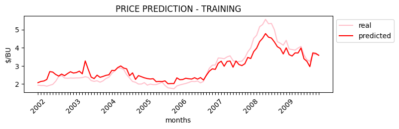

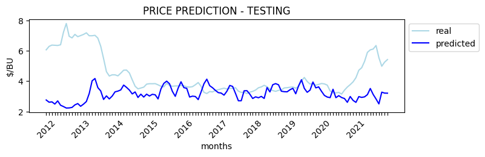

```python
# forge the labels
labels_train = np.where(y_train['MONTH'] == 1,y_train['YEAR'].astype(str), "")
labels_test = np.where(y_test ['MONTH'] == 1, y_test['YEAR'].astype(str), "")
# plot training performance
ticks = range(y_train.shape[0])
plt.figure(figsize=(8, 2))
plt.plot(ticks, y_train["PRICE"], color='pink', label="real")
plt.plot(ticks, y_train_predict, color='red', label="predicted")
plt.xticks(ticks=ticks, labels=labels_train, rotation=45)
plt.title("PRICE PREDICTION - TRAINING")
plt.ylabel("$/BU")
plt.xlabel("months")
plt.legend(loc='upper left', bbox_to_anchor=(1, 1))
# plot testing performance
ticks = range(y_test.shape[0])
plt.figure(figsize=(8, 2))
plt.plot(ticks, y_test["PRICE"], color='lightblue', label="real")
plt.plot(ticks, y_test_predict, color='blue', label="predicted")
plt.xticks(ticks=ticks, labels=labels_test, rotation=45)
plt.title("PRICE PREDICTION - TESTING")
plt.ylabel("$/BU")
plt.xlabel("months")
plt.legend(loc='upper left', bbox_to_anchor=(1, 1));
```

## REGRESSION ON WEATHER OUTLIERS TO PREDICT PRICE OUTLIERS

IDEA: Exceptional weather events, such as flooding or freezing days, may drastically impact production and price, more than the average monthly temperature.

- Model: linear regression
- Output: Economical outlier: positive and negative months in terms of future contracts (from future contract EDA)
- Features: Colder, hotter, drier and wetter month that is for months with the highest number of outliers when the seasonal trend is subtracted (from weather EDA).

We train a linear model using data from 1992 to 2010 (since there is no weather data for 2010) and test it using data from 2011 to 2017. We print the accuracy of the prediction using MSE, MAE, and R-squared, and we plot both the real and predicted data for training and testing. The values of these metrics are not bad, but the overall performance in predicting negative and positive months is not good. We may need a more powerful model, or there may not be enough correlation between prices and weather.

```python
# model training
model = LinearRegression()
model.fit(X_train, y_train)
# prediction
y_train_predict = model.predict(X_train)
y_test_predict = model.predict(X_test)
# training performance
print("TRAINING PERFORMANCE:")
print("Mean Squared Error:", mean_squared_error(y_train, y_train_predict))
print("Mean Absolute Error (MAE):", mean_absolute_error(y_train, y_train_predict))
print("R² Score:", r2_score(y_train, y_train_predict))
# testing performance
print("\nTESTING PERFORMANCE:")
print("Mean Squared Error:", mean_squared_error(y_test, y_test_predict))
print("Mean Absolute Error (MAE):", mean_absolute_error(y_test, y_test_predict))
print("R² Score:", r2_score(y_test, y_test_predict))
```

```
TRAINING PERFORMANCE:
Mean Squared Error: 0.09962749989465056
Mean Absolute Error (MAE): 0.19972907233101972
R² Score: 0.026015456955722438

TESTING PERFORMANCE:
Mean Squared Error: 0.12491737154389035
Mean Absolute Error (MAE): 0.22737080907559548
R² Score: 0.04283609597017485
```

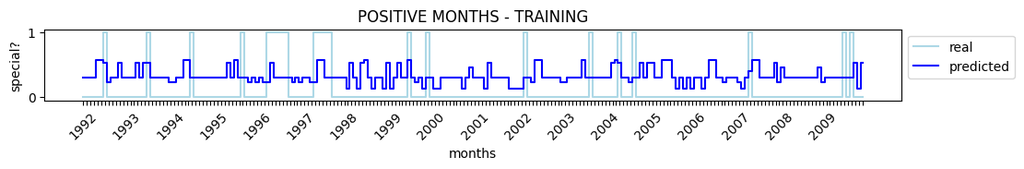

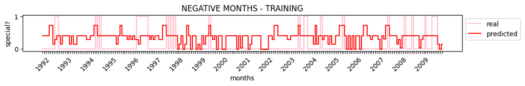

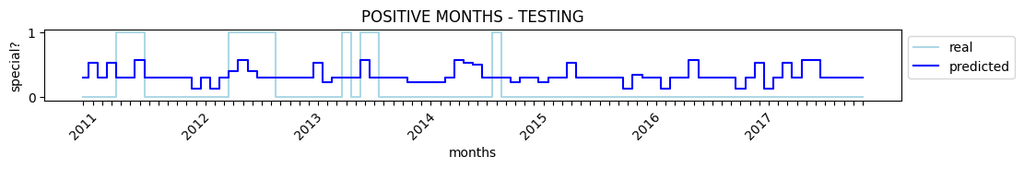

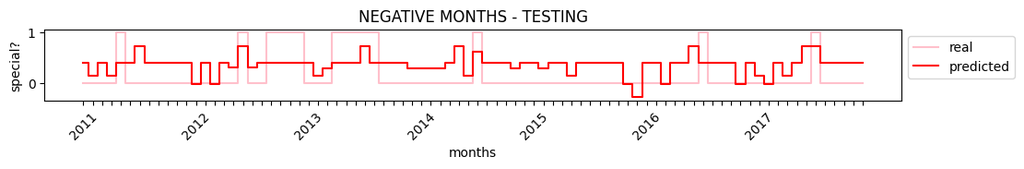

```python
# forge the labels
labels_train = np.where(weather_t[weather_t['YEAR']<split]['MONTH'] == 1, weather_t[weather_t['YEAR']<split]['YEAR'].astype(str), "")
labels_test = np.where(weather_t[weather_t['YEAR']>split]['MONTH'] == 1, weather_t[weather_t['YEAR']>split]['YEAR'].astype(str), "")
amplify = 3
# plot training performance
ticks = range(y_train.shape[0])
plt.figure(figsize=(12, 1))
plt.step(ticks, y_train["positive"], where='mid', color='lightblue', label="real")
plt.step(ticks, y_train_predict[:, 0]*amplify, where='mid', color='blue', label="predicted")
plt.xticks(ticks=ticks, labels=labels_train, rotation=45)
plt.title("POSITIVE MONTHS - TRAINING")
plt.xlabel("months")
plt.ylabel("special?")
plt.legend(loc='upper left', bbox_to_anchor=(1, 1))
plt.figure(figsize=(12, 1))
plt.step(ticks, y_train["negative"], where='mid', color='pink', label="real")
plt.step(ticks, y_train_predict[:, 1]*amplify, where='mid', color='red', label="predicted")
plt.xticks(ticks=ticks, labels=labels_train, rotation=45)
plt.title("NEGATIVE MONTHS - TRAINING")
plt.xlabel("months")
plt.ylabel("special?")
plt.legend(loc='upper left', bbox_to_anchor=(1, 1))
# plot testing performance
ticks = range(y_test.shape[0])
plt.figure(figsize=(12, 1))
plt.step(ticks, y_test["positive"], where='mid', color='lightblue', label="real")
plt.step(ticks, y_test_predict[:, 0]*amplify, where='mid', color='blue', label="predicted")
plt.xticks(ticks=ticks, labels=labels_test, rotation=45)
plt.title("POSITIVE MONTHS - TESTING")
plt.xlabel("months")
plt.ylabel("special?")
plt.legend(loc='upper left', bbox_to_anchor=(1, 1))
plt.figure(figsize=(12, 1))
plt.step(ticks, y_test["negative"], where='mid', color='pink', label="real")
plt.step(ticks, y_test_predict[:, 1]*amplify, where='mid', color='red', label="predicted")
plt.xticks(ticks=ticks, labels=labels_test, rotation=45)
plt.title("NEGATIVE MONTHS - TESTING")
plt.xlabel("months")
plt.ylabel("special?")
plt.legend(loc='upper left', bbox_to_anchor=(1, 1));
```

### Neural Nework prediction for corn prices

IDEA: Use a more powerful model for a more complex prediction

Features: Minimum temperature, maximum temperature and precipitation average in the corn belt for the previous 24 months.

Output: Corn price for the next 4 months

**SPLIT INTO SEQUENCES OF 28: 24 months for X and 4 for prediction**

```python
def create_sequences(data, seq_length, stride=1):
    x = []
    for i in range(0, len(data) - seq_length + 1, stride):
        x.append(data[i:i+seq_length])
    return np.array(x)
# Sequence length
seq_length = 28
telescope = 4
# Dictionary to store training sequences for each stock
x = []
for state, group in weather_corn_scaled.groupby('STATE'):
    if len(group) >= seq_length:
        x_temp = create_sequences(group[['TMAX', 'TMIN', 'PRCP', 'PRICE']], seq_length, stride = 3)
        x.append(x_temp)
    else:
        print(f"Warning: Not enough data for {state}. Needed {seq_length}, but only had {len(group)}")
x = np.concatenate(x, axis=0)
print(x.shape)
```

```
(994, 28, 4)
```

**SPLIT DATA IN TRAIN AND TEST with test 10% size**

```python
def split_xy(data, telescope):
    x = data[:, :-telescope]
    y = data[:, -telescope:, -1]
    return x, y

test_size = round(len(x) * 0.1)
train_size = len(x) - test_size
#dataset split
train = x[:train_size]
test = x[train_size:]
#split dataset into data and prediction
x_train, y_train = split_xy(train, telescope)
x_test, y_test = split_xy(test, telescope)
print(x_train.shape, y_train.shape, x_test.shape, y_test.shape)
```

```
(895, 24, 4) (895, 4) (99, 24, 4) (99, 4)
```

```python
input_size = x_train.shape[1:]
output_size = y_train.shape[1]
input_size, output_size
```

```
((24, 4), 4)
```

**MODEL ARCHITECTURE**

```python
#model architecture
def buildModel(input_shape, output_shape):
    input_layer = tfkl.Input(shape=input_shape, name='Input')
    x = tfkl.LSTM(128, return_sequences = True, name='lstm')(input_layer)
    cnn = tfkl.Conv1D(128,3,padding = 'same', activation = 'relu')(x)
    cnn = tfkl.MaxPooling1D()(cnn)
    cnn = tfkl.Conv1D(256,3,padding = 'same', activation = 'relu')(cnn)
    cnn = tfkl.MaxPooling1D()(cnn)
    cnn = tfkl.Conv1D(512,3,padding = 'same', activation = 'relu')(cnn)
    gap = tfkl.GlobalAveragePooling1D()(cnn)
    dropout = tfkl.Dropout(.25, seed = seed)(gap)
    dense = tfkl.Dense(512, activation = tf.keras.activations.mish, kernel_constraint=tfk.constraints.MaxNorm(1.5))(dropout)
    dropout = tfkl.Dropout(.1, seed = seed)(dense)
    dense = tfkl.Dense(128, activation = tf.keras.activations.mish, kernel_constraint=tfk.constraints.MaxNorm(1.5))(dropout)
    output_layer = tfkl.Dense(output_shape, activation = 'linear')(dense)
    model = tf.keras.Model(inputs = input_layer, outputs = output_layer, name='LSTMCNN_Model')
    model.compile(
    loss=tf.keras.losses.MeanSquaredError(),
    optimizer=tf.keras.optimizers.Adam(
        learning_rate=0.001,
        beta_1=0.9,
        beta_2=0.999,
        epsilon=1e-07,
        weight_decay=0.004,  # Adam doesn't officially have weight decay in Keras, but you can simulate it
        name="Adam"
    ),
    metrics=[tf.keras.metrics.MeanAbsoluteError()])
    return model
```

```python
model = buildModel(input_size, output_size)
model.summary()
```

```
Model: "LSTMCNN_Model"
```

```
┏━━━━━━━━━━━━━━━━━━━━━━━━━━━━━━━━━━━━━━┳━━━━━━━━━━━━━━━━━━━━━━━━━━━━━┳━━━━━━━━━━━━━━━━━┓
┃ Layer (type)                         ┃ Output Shape                ┃         Param # ┃
┡━━━━━━━━━━━━━━━━━━━━━━━━━━━━━━━━━━━━━━╇━━━━━━━━━━━━━━━━━━━━━━━━━━━━━╇━━━━━━━━━━━━━━━━━┩
│ Input (InputLayer)                   │ (None, 24, 4)               │               0 │
├──────────────────────────────────────┼─────────────────────────────┼─────────────────┤
│ lstm (LSTM)                          │ (None, 24, 128)             │          68,096 │
├──────────────────────────────────────┼─────────────────────────────┼─────────────────┤
│ conv1d (Conv1D)                      │ (None, 24, 128)             │          49,280 │
├──────────────────────────────────────┼─────────────────────────────┼─────────────────┤
│ max_pooling1d (MaxPooling1D)         │ (None, 12, 128)             │               0 │
├──────────────────────────────────────┼─────────────────────────────┼─────────────────┤
│ conv1d_1 (Conv1D)                    │ (None, 12, 256)             │          98,560 │
├──────────────────────────────────────┼─────────────────────────────┼─────────────────┤
│ max_pooling1d_1 (MaxPooling1D)       │ (None, 6, 256)              │               0 │
├──────────────────────────────────────┼─────────────────────────────┼─────────────────┤
│ conv1d_2 (Conv1D)                    │ (None, 6, 512)              │         393,728 │
├──────────────────────────────────────┼─────────────────────────────┼─────────────────┤
│ global_average_pooling1d             │ (None, 512)                 │               0 │
│ (GlobalAveragePooling1D)             │                             │                 │
├──────────────────────────────────────┼─────────────────────────────┼─────────────────┤
│ dropout (Dropout)                    │ (None, 512)                 │               0 │
├──────────────────────────────────────┼─────────────────────────────┼─────────────────┤
│ dense (Dense)                        │ (None, 512)                 │         262,656 │
├──────────────────────────────────────┼─────────────────────────────┼─────────────────┤
│ dropout_1 (Dropout)                  │ (None, 512)                 │               0 │
├──────────────────────────────────────┼─────────────────────────────┼─────────────────┤
│ dense_1 (Dense)                      │ (None, 128)                 │          65,664 │
├──────────────────────────────────────┼─────────────────────────────┼─────────────────┤
│ dense_2 (Dense)                      │ (None, 4)                   │             516 │
└──────────────────────────────────────┴─────────────────────────────┴─────────────────┘
```

```
 Total params: 938,500 (3.58 MB)
```

```
 Trainable params: 938,500 (3.58 MB)
```

```
 Non-trainable params: 0 (0.00 B)
```

```python
calls = [
            tfk.callbacks.EarlyStopping(monitor = 'val_loss', mode = 'min', patience = 40, restore_best_weights = True),
            tfk.callbacks.ReduceLROnPlateau(monitor = 'val_loss', mode = 'min', patience = 20, factor = 0.4, min_lr = 1e-5)
      ]
```

```python
history = model.fit(
    x = x_train,
    y = y_train,
    batch_size = 64,
    epochs = 300,
    validation_split = .2,
    callbacks = calls
).history
```

***GET A RANDOM SAMPLE OF Y TO MAKE PREDICTION (WITHOUT RESCALING FOR SPACE, PLEASE VIEW FULL COLAB FOR MORE ANALYSIS).***

```
1/1 ━━━━━━━━━━━━━━━━━━━━ 0s 240ms/step
```

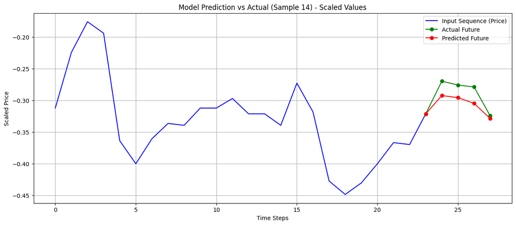

```
Numerical Comparison (Scaled Values):
Actual values: [-0.26969697 -0.27575758 -0.27878788 -0.32424242]
Predicted values: [-0.29240623 -0.2956235  -0.3047381  -0.32849428]
Mean Absolute Error: 0.0182
```

```python
# Get a random sample from test set
sample_index = random.randrange(0, x_test.shape[0])
x_sample = x_test[sample_index]
y_actual = y_test[sample_index]
#make prediction
y_pred = model.predict(x_sample[np.newaxis, :, :])[0]
plt.figure(figsize=(15, 6))
plt.plot(range(len(x_sample)), x_sample[:, -1],
         label='Input Sequence (Price)', color='blue')
# plot actual vs predicted values
plt.plot(range(len(x_sample)-1, len(x_sample) + len(y_actual)),
         [x_sample[-1, -1]] + list(y_actual),
         label='Actual Future', color='green', marker='o')
plt.plot(range(len(x_sample)-1, len(x_sample) + len(y_pred)),
         [x_sample[-1, -1]] + list(y_pred),
         label='Predicted Future', color='red', marker='o')
plt.title(f'Model Prediction vs Actual (Sample {sample_index}) - Scaled Values')
plt.xlabel('Time Steps')
plt.ylabel('Scaled Price')
plt.legend()
plt.grid(True)
plt.show()
# print numerical comparison
print("\nNumerical Comparison (Scaled Values):")
print(f"Actual values: {y_actual}")
print(f"Predicted values: {y_pred}")
print(f"Mean Absolute Error: {np.mean(np.abs(y_actual - y_pred)):.4f}")
```